# Homework 4 - BSTA 519

Matthew Hoctor

10/31/2021

Toenail Data: Parametric & Semi-Parametric Curves

# Dental Data import

Import the ‘dental’ dataset:

```r
dent <- read_csv("dent.csv")
```

Create factored long-form data:

```r
dent_long <- pivot_longer(data = dent, cols = c("8", "10","12", "14"), names_to = "age", values_to = "distance")
```

# 1.1

On a single graph, construct a time plot that displays the mean distance (mm) vs. age (in years)) for boys and girls. Describe the time trends for boys and girls.

```r
mm_mean <- dent_long %>% group_by(Gender, age) %>% summarise(mm = mean(distance))
```

Creating a factored gender variable for ggplot:

```r
mm_mean$Gender.f <- factor(mm_mean$Gender, c("F", "M"))
```

Creating a numeric age variable:

```r
mm_mean$age <- as.numeric(mm_mean$age)
```

Plotting with ggplot:

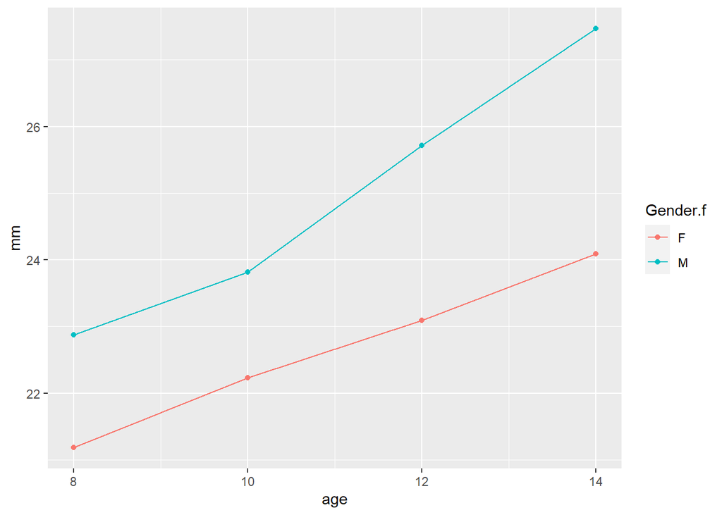

```r
ggplot(data = mm_mean,
       mapping = aes(
         x = age,
         y = mm,
         colour = Gender.f,
         group = Gender
         )) +
  geom_line() + geom_point()
```

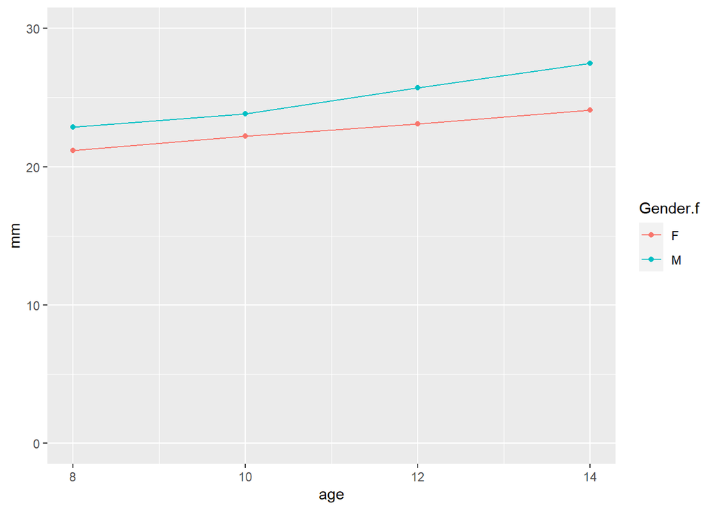

```r
ggplot(data = mm_mean,
       mapping = aes(
         x = age,
         y = mm,
         colour = Gender.f,
         group = Gender
         )) +
  geom_line() + geom_point()+coord_cartesian(ylim = c(0,30))
```

As we can see from the plots above, the average dental growth distance increases with age for female and male children over the ages considered; however the average dental growth distance for males is greater throughout the age range. Plotting such that the graph of the response variable includes the null shows that the relative increases are somewhat small, overall.

# 1.2

Provide the estimated covariance and correlation matrix from the data, and describe how the variance and correlation change over time.

To provide a qualitative visualization, see below for the scatterplot matrix:

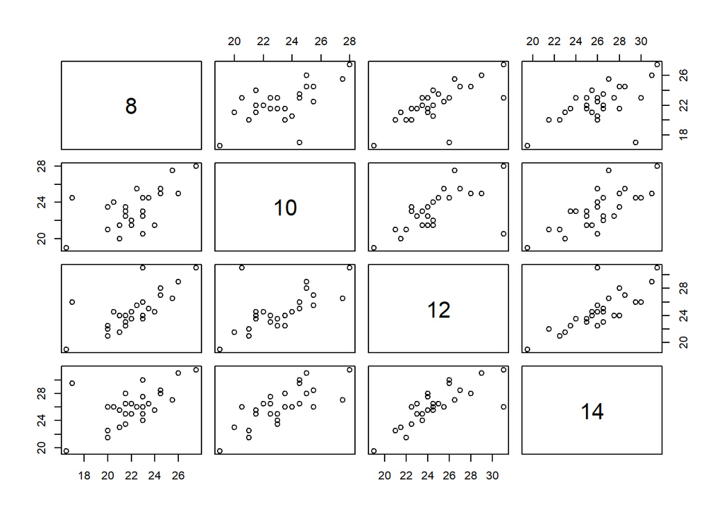

```r
pairs(dent[,3:6])
```

To calculate the correlation matrix:

```r
round(cor(dent[, 3:6]), 4)
```

```
##         8     10     12     14
## 8  1.0000 0.6256 0.7108 0.5998
## 10 0.6256 1.0000 0.6349 0.7593
## 12 0.7108 0.6349 1.0000 0.7950
## 14 0.5998 0.7593 0.7950 1.0000
```

To calculate the covariance matrix:

```r
round(cov(dent[, 3:6]), 4)
```

```
##         8     10     12     14
## 8  5.9259 3.2853 4.8754 4.0399
## 10 3.2853 4.6538 3.8590 4.5321
## 12 4.8754 3.8590 7.9387 6.1973
## 14 4.0399 4.5321 6.1973 7.6546
```

Although we would expect to see decreasing correlation over time; no distinct pattern of change in correlation or covariance is immediately apparent from these matricies. Increasing variance (along the diagonal of the covariance matrix) is possible, but not completely apparent.

# 1.3

## Fitting Models

Use the response profile model (saturated model for the mean response) as the maximal model for the mean, fit the following models for covariance:

First we will convert age to a numerical variable in the long-form dataset:

```r
dent_long$age <- as.numeric(dent_long$age)
```

Then create factored variables for age and gender:

```r
dent_long$Gender.f <- factor(dent_long$Gender, c("F", "M"))
dent_long$age.f <- factor(dent_long$age, c(8,10,12,14))
```

Then create a ‘time’ variable so that corSymm doesn’t complain about ‘objects must be a sequence of consecutive integers’:

```r
dent_long$time = dent_long$age
dent_long$time[dent_long$age == 8] = 1
dent_long$time[dent_long$age == 10] = 2
dent_long$time[dent_long$age == 12] = 3
dent_long$time[dent_long$age == 14] = 4
```

### i. Unstructured covariance

Creating the model:

```r
dent_reml_uns <- gls(distance ~ Gender.f*age.f,
                     data = dent_long,
                     corr = corSymm(form = ~ time | ID),       # it does not run if use form =  ~ age | ID
                     weights = varIdent(form = ~ 1 | age),
                     method = "REML"
                     )
```

Summary:

```r
summary(dent_reml_uns)
```

```
## Generalized least squares fit by REML
##   Model: distance ~ Gender.f * age.f
##   Data: dent_long
##        AIC      BIC    logLik
##   450.0348 496.9279 -207.0174
##
## Correlation Structure: General
##  Formula: ~time | ID
##  Parameter estimate(s):
##  Correlation:
##   1     2     3
## 2 0.571
## 3 0.661 0.563
## 4 0.522 0.726 0.728
## Variance function:
##  Structure: Different standard deviations per stratum
##  Formula: ~1 | age
##  Parameter estimates:
##         8        10        12        14
## 1.0000000 0.8790601 1.0918305 0.9595050
##
## Coefficients:
##                       Value Std.Error   t-value p-value
## (Intercept)       21.181818 0.7016511 30.188534  0.0000
## Gender.fM          1.693182 0.9114715  1.857635  0.0662
## age.f10            1.045455 0.6154516  1.698679  0.0925
## age.f12            1.909091 0.6068358  3.145976  0.0022
## age.f14            2.909091 0.6728998  4.323216  0.0000
## Gender.fM:age.f10 -0.107955 0.7994951 -0.135028  0.8929
## Gender.fM:age.f12  0.934659 0.7883028  1.185660  0.2386
## Gender.fM:age.f14  1.684659 0.8741224  1.927258  0.0568
##
##  Correlation:
##                   (Intr) Gndr.M ag.f10 ag.f12 ag.f14 G.M:.10 G.M:.12
## Gender.fM         -0.770
## age.f10           -0.568  0.437
## age.f12           -0.321  0.247  0.418
## age.f14           -0.521  0.401  0.726  0.651
## Gender.fM:age.f10  0.437 -0.568 -0.770 -0.321 -0.559
## Gender.fM:age.f12  0.247 -0.321 -0.321 -0.770 -0.501  0.418
## Gender.fM:age.f14  0.401 -0.521 -0.559 -0.501 -0.770  0.726   0.651
##
## Standardized residuals:
##         Min          Q1         Med          Q3         Max
## -2.52458687 -0.64159832 -0.07813035  0.59313659  2.07856661
##
## Residual standard error: 2.327113
## Degrees of freedom: 108 total; 100 residual
```

Type III test:

```r
anova(dent_reml_uns)
```

```
## Denom. DF: 100
##                numDF  F-value p-value
## (Intercept)        1 4246.072  <.0001
## Gender.f           1    7.719  0.0065
## age.f              3   39.441  <.0001
## Gender.f:age.f     3    2.930  0.0373
```

Covariance & Correlation:

```r
#obtain covariance structure
getVarCov(dent_reml_uns)
```

```
## Marginal variance covariance matrix
##        [,1]   [,2]   [,3]   [,4]
## [1,] 5.4155 2.7168 3.9102 2.7102
## [2,] 2.7168 4.1848 2.9272 3.3172
## [3,] 3.9102 2.9272 6.4557 4.1307
## [4,] 2.7102 3.3172 4.1307 4.9857
##   Standard Deviations: 2.3271 2.0457 2.5408 2.2329
```

```r
#obtain correlation matrix
dent_reml_uns_cov <- getVarCov(dent_reml_uns)
dent_reml_uns_cov
```

```
## Marginal variance covariance matrix
##        [,1]   [,2]   [,3]   [,4]
## [1,] 5.4155 2.7168 3.9102 2.7102
## [2,] 2.7168 4.1848 2.9272 3.3172
## [3,] 3.9102 2.9272 6.4557 4.1307
## [4,] 2.7102 3.3172 4.1307 4.9857
##   Standard Deviations: 2.3271 2.0457 2.5408 2.2329
```

```r
cov2cor(dent_reml_uns_cov)
```

```
## Marginal variance covariance matrix
##         [,1]    [,2]    [,3]    [,4]
## [1,] 1.00000 0.57070 0.66132 0.52158
## [2,] 0.57070 1.00000 0.56317 0.72622
## [3,] 0.66132 0.56317 1.00000 0.72810
## [4,] 0.52158 0.72622 0.72810 1.00000
##   Standard Deviations: 1 1 1 1
```

```r
is.matrix(dent_reml_uns_cov)
```

```
## [1] TRUE
```

```r
#Obtain correlation parameters
dent_reml_uns_MS <- dent_reml_uns$modelStruct
dent_reml_uns_MS$corStruct
```

```
## Correlation structure of class corSymm representing
##  Correlation:
##   1     2     3
## 2 0.571
## 3 0.661 0.563
## 4 0.522 0.726 0.728
```

```r
dent_reml_uns_MS$varStruct
```

```
## Variance function structure of class varIdent representing
##         8        10        12        14
## 1.0000000 0.8790601 1.0918305 0.9595050
```

### ii. Compound symmetry

Creating the model:

```r
dent_reml_cs <- gls(distance ~ Gender.f*age.f,
                     data = dent_long,
                     corr = corCompSymm(form = ~ time | ID),       # it does not run if use form =  ~ age | ID
                     #weights = varIdent(form = ~ 1 | age),
                     method = "REML"
                     )
```

Summary:

```r
summary(dent_reml_cs)
```

```
## Generalized least squares fit by REML
##   Model: distance ~ Gender.f * age.f
##   Data: dent_long
##        AIC      BIC    logLik
##   443.4085 469.4602 -211.7043
##
## Correlation Structure: Compound symmetry
##  Formula: ~time | ID
##  Parameter estimate(s):
##       Rho
## 0.6245472
##
## Coefficients:
##                       Value Std.Error   t-value p-value
## (Intercept)       21.181818 0.6915345 30.630168  0.0000
## Gender.fM          1.693182 0.8983297  1.884811  0.0624
## age.f10            1.045455 0.5992479  1.744611  0.0841
## age.f12            1.909091 0.5992479  3.185812  0.0019
## age.f14            2.909091 0.5992479  4.854570  0.0000
## Gender.fM:age.f10 -0.107955 0.7784458 -0.138680  0.8900
## Gender.fM:age.f12  0.934659 0.7784458  1.200673  0.2327
## Gender.fM:age.f14  1.684659 0.7784458  2.164131  0.0328
##
##  Correlation:
##                   (Intr) Gndr.M ag.f10 ag.f12 ag.f14 G.M:.10 G.M:.12
## Gender.fM         -0.770
## age.f10           -0.433  0.334
## age.f12           -0.433  0.334  0.500
## age.f14           -0.433  0.334  0.500  0.500
## Gender.fM:age.f10  0.334 -0.433 -0.770 -0.385 -0.385
## Gender.fM:age.f12  0.334 -0.433 -0.385 -0.770 -0.385  0.500
## Gender.fM:age.f14  0.334 -0.433 -0.385 -0.385 -0.770  0.500   0.500
##
## Standardized residuals:
##         Min          Q1         Med          Q3         Max
## -2.56151951 -0.60972339 -0.07927333  0.61436832  2.30264254
##
## Residual standard error: 2.293561
## Degrees of freedom: 108 total; 100 residual
```

Type III test:

```r
anova(dent_reml_cs)
```

```
## Denom. DF: 100
##                numDF  F-value p-value
## (Intercept)        1 4123.164  <.0001
## Gender.f           1    9.292  0.0029
## age.f              3   40.032  <.0001
## Gender.f:age.f     3    2.362  0.0759
```

Covariance & Correlation:

```r
#obtain covariance structure
getVarCov(dent_reml_cs)
```

```
## Marginal variance covariance matrix
##        [,1]   [,2]   [,3]   [,4]
## [1,] 5.2604 3.2854 3.2854 3.2854
## [2,] 3.2854 5.2604 3.2854 3.2854
## [3,] 3.2854 3.2854 5.2604 3.2854
## [4,] 3.2854 3.2854 3.2854 5.2604
##   Standard Deviations: 2.2936 2.2936 2.2936 2.2936
```

```r
#obtain correlation matrix
dent_reml_cs_cov <- getVarCov(dent_reml_cs)
dent_reml_cs_cov
```

```
## Marginal variance covariance matrix
##        [,1]   [,2]   [,3]   [,4]
## [1,] 5.2604 3.2854 3.2854 3.2854
## [2,] 3.2854 5.2604 3.2854 3.2854
## [3,] 3.2854 3.2854 5.2604 3.2854
## [4,] 3.2854 3.2854 3.2854 5.2604
##   Standard Deviations: 2.2936 2.2936 2.2936 2.2936
```

```r
cov2cor(dent_reml_cs_cov)
```

```
## Marginal variance covariance matrix
##         [,1]    [,2]    [,3]    [,4]
## [1,] 1.00000 0.62455 0.62455 0.62455
## [2,] 0.62455 1.00000 0.62455 0.62455
## [3,] 0.62455 0.62455 1.00000 0.62455
## [4,] 0.62455 0.62455 0.62455 1.00000
##   Standard Deviations: 1 1 1 1
```

```r
is.matrix(dent_reml_cs_cov)
```

```
## [1] TRUE
```

```r
#Obtain correlation parameters
dent_reml_cs_MS <- dent_reml_cs$modelStruct
dent_reml_cs_MS$corStruct
```

```
## Correlation structure of class corCompSymm representing
##       Rho
## 0.6245472
```

```r
dent_reml_cs_MS$varStruct
```

### iii. Heterogeneous Compound symmetry

Creating the model:

```r
dent_reml_csh <- gls(distance ~ Gender.f*age.f,
                     data = dent_long,
                     corr = corCompSymm(form = ~ time | ID),       # it does not run if use form =  ~ age | ID
                     weights = varIdent(form = ~ 1 | age),
                     method = "REML"
                     )
```

Summary:

```r
summary(dent_reml_csh)
```

```
## Generalized least squares fit by REML
##   Model: distance ~ Gender.f * age.f
##   Data: dent_long
##        AIC      BIC    logLik
##   447.4236 481.2908 -210.7118
##
## Correlation Structure: Compound symmetry
##  Formula: ~time | ID
##  Parameter estimate(s):
##       Rho
## 0.6292086
## Variance function:
##  Structure: Different standard deviations per stratum
##  Formula: ~1 | age
##  Parameter estimates:
##         8        10        12        14
## 1.0000000 0.8628409 1.0552745 0.9234401
##
## Coefficients:
##                       Value Std.Error   t-value p-value
## (Intercept)       21.181818 0.7179571 29.502904  0.0000
## Gender.fM          1.693182 0.9326536  1.815446  0.0725
## age.f10            1.045455 0.5826878  1.794193  0.0758
## age.f12            1.909091 0.6363663  2.999988  0.0034
## age.f14            2.909091 0.5966689  4.875553  0.0000
## Gender.fM:age.f10 -0.107955 0.7569337 -0.142621  0.8869
## Gender.fM:age.f12  0.934659 0.8266641  1.130640  0.2609
## Gender.fM:age.f14  1.684659 0.7750956  2.173486  0.0321
##
##  Correlation:
##                   (Intr) Gndr.M ag.f10 ag.f12 ag.f14 G.M:.10 G.M:.12
## Gender.fM         -0.770
## age.f10           -0.563  0.434
## age.f12           -0.379  0.292  0.509
## age.f14           -0.504  0.388  0.560  0.500
## Gender.fM:age.f10  0.434 -0.563 -0.770 -0.392 -0.431
## Gender.fM:age.f12  0.292 -0.379 -0.392 -0.770 -0.385  0.509
## Gender.fM:age.f14  0.388 -0.504 -0.431 -0.385 -0.770  0.560   0.500
##
## Standardized residuals:
##         Min          Q1         Med          Q3         Max
## -2.46724940 -0.63881301 -0.07635588  0.59368504  2.10172783
##
## Residual standard error: 2.381194
## Degrees of freedom: 108 total; 100 residual
```

Type III test:

```r
anova(dent_reml_csh)
```

```
## Denom. DF: 100
##                numDF  F-value p-value
## (Intercept)        1 4366.263  <.0001
## Gender.f           1    9.001  0.0034
## age.f              3   41.679  <.0001
## Gender.f:age.f     3    2.593  0.0568
```

Covariance & Correlation:

```r
#obtain covariance structure
getVarCov(dent_reml_csh)
```

```
## Marginal variance covariance matrix
##        [,1]   [,2]   [,3]   [,4]
## [1,] 5.6701 3.0783 3.7649 3.2945
## [2,] 3.0783 4.2213 3.2485 2.8427
## [3,] 3.7649 3.2485 6.3142 3.4766
## [4,] 3.2945 2.8427 3.4766 4.8351
##   Standard Deviations: 2.3812 2.0546 2.5128 2.1989
```

```r
#obtain correlation matrix
dent_reml_csh_cov <- getVarCov(dent_reml_csh)
dent_reml_csh_cov
```

```
## Marginal variance covariance matrix
##        [,1]   [,2]   [,3]   [,4]
## [1,] 5.6701 3.0783 3.7649 3.2945
## [2,] 3.0783 4.2213 3.2485 2.8427
## [3,] 3.7649 3.2485 6.3142 3.4766
## [4,] 3.2945 2.8427 3.4766 4.8351
##   Standard Deviations: 2.3812 2.0546 2.5128 2.1989
```

```r
cov2cor(dent_reml_csh_cov)
```

```
## Marginal variance covariance matrix
##         [,1]    [,2]    [,3]    [,4]
## [1,] 1.00000 0.62921 0.62921 0.62921
## [2,] 0.62921 1.00000 0.62921 0.62921
## [3,] 0.62921 0.62921 1.00000 0.62921
## [4,] 0.62921 0.62921 0.62921 1.00000
##   Standard Deviations: 1 1 1 1
```

```r
is.matrix(dent_reml_csh_cov)
```

```
## [1] TRUE
```

```r
#Obtain correlation parameters
dent_reml_csh_MS <- dent_reml_csh$modelStruct
dent_reml_csh_MS$corStruct
```

```
## Correlation structure of class corCompSymm representing
##       Rho
## 0.6292086
```

```r
dent_reml_csh_MS$varStruct
```

```
## Variance function structure of class varIdent representing
##         8        10        12        14
## 1.0000000 0.8628409 1.0552745 0.9234401
```

#### Compare compound symmetry to heterogenious compound symmetry

```r
anova(dent_reml_cs, dent_reml_csh, test = TRUE)
```

```
##               Model df      AIC      BIC    logLik   Test  L.Ratio p-value
## dent_reml_cs      1 10 443.4085 469.4602 -211.7043
## dent_reml_csh     2 13 447.4236 481.2908 -210.7118 1 vs 2 1.984932  0.5755
```

### iv. Autoregressive(1)

Creating the model:

```r
dent_reml_ar1 <- gls(distance ~ Gender.f*age.f,
                     data = dent_long,
                     corr = corAR1(form = ~ time | ID),       # it does not run if use form =  ~ age | ID
                     #weights = varIdent(form = ~ 1 | age),
                     method = "REML"
                     )
```

Summary:

```r
summary(dent_reml_ar1)
```

```
## Generalized least squares fit by REML
##   Model: distance ~ Gender.f * age.f
##   Data: dent_long
##        AIC      BIC    logLik
##   454.5472 480.5989 -217.2736
##
## Correlation Structure: AR(1)
##  Formula: ~time | ID
##  Parameter estimate(s):
##       Phi
## 0.6152662
##
## Coefficients:
##                       Value Std.Error   t-value p-value
## (Intercept)       21.181818 0.6906162 30.670897  0.0000
## Gender.fM          1.693182 0.8971368  1.887317  0.0620
## age.f10            1.045455 0.6058037  1.725732  0.0875
## age.f12            1.909091 0.7699348  2.479549  0.0148
## age.f14            2.909091 0.8554108  3.400811  0.0010
## Gender.fM:age.f10 -0.107955 0.7869621 -0.137179  0.8912
## Gender.fM:age.f12  0.934659 1.0001747  0.934496  0.3523
## Gender.fM:age.f14  1.684659 1.1112113  1.516057  0.1327
##
##  Correlation:
##                   (Intr) Gndr.M ag.f10 ag.f12 ag.f14 G.M:.10 G.M:.12
## Gender.fM         -0.770
## age.f10           -0.439  0.338
## age.f12           -0.557  0.429  0.635
## age.f14           -0.619  0.477  0.488  0.727
## Gender.fM:age.f10  0.338 -0.439 -0.770 -0.489 -0.376
## Gender.fM:age.f12  0.429 -0.557 -0.489 -0.770 -0.560  0.635
## Gender.fM:age.f14  0.477 -0.619 -0.376 -0.560 -0.770  0.488   0.727
##
## Standardized residuals:
##         Min          Q1         Med          Q3         Max
## -2.56492558 -0.61053415 -0.07937874  0.61518525  2.30570438
##
## Residual standard error: 2.290515
## Degrees of freedom: 108 total; 100 residual
```

Type III test:

```r
anova(dent_reml_ar1)
```

```
## Denom. DF: 100
##                numDF  F-value p-value
## (Intercept)        1 5114.073  <.0001
## Gender.f           1   12.438  0.0006
## age.f              3   17.495  <.0001
## Gender.f:age.f     3    1.125  0.3428
```

Covariance & Correlation:

```r
#obtain covariance structure
getVarCov(dent_reml_ar1)
```

```
## Marginal variance covariance matrix
##        [,1]   [,2]   [,3]   [,4]
## [1,] 5.2465 3.2280 1.9861 1.2220
## [2,] 3.2280 5.2465 3.2280 1.9861
## [3,] 1.9861 3.2280 5.2465 3.2280
## [4,] 1.2220 1.9861 3.2280 5.2465
##   Standard Deviations: 2.2905 2.2905 2.2905 2.2905
```

```r
#obtain correlation matrix
dent_reml_ar1_cov <- getVarCov(dent_reml_ar1)
dent_reml_ar1_cov
```

```
## Marginal variance covariance matrix
##        [,1]   [,2]   [,3]   [,4]
## [1,] 5.2465 3.2280 1.9861 1.2220
## [2,] 3.2280 5.2465 3.2280 1.9861
## [3,] 1.9861 3.2280 5.2465 3.2280
## [4,] 1.2220 1.9861 3.2280 5.2465
##   Standard Deviations: 2.2905 2.2905 2.2905 2.2905
```

```r
cov2cor(dent_reml_ar1_cov)
```

```
## Marginal variance covariance matrix
##         [,1]    [,2]    [,3]    [,4]
## [1,] 1.00000 0.61527 0.37855 0.23291
## [2,] 0.61527 1.00000 0.61527 0.37855
## [3,] 0.37855 0.61527 1.00000 0.61527
## [4,] 0.23291 0.37855 0.61527 1.00000
##   Standard Deviations: 1 1 1 1
```

```r
is.matrix(dent_reml_ar1_cov)
```

```
## [1] TRUE
```

```r
#Obtain correlation parameters
dent_reml_ar1_MS <- dent_reml_ar1$modelStruct
dent_reml_ar1_MS$corStruct
```

```
## Correlation structure of class corAR1 representing
##       Phi
## 0.6152662
```

```r
dent_reml_ar1_MS$varStruct
```

### v. Heterogeneous autoregressive(1)

Creating the model:

```r
dent_reml_ar1h <- gls(distance ~ Gender.f*age.f,
                     data = dent_long,
                     corr = corAR1(form = ~ time | ID),       # it does not run if use form =  ~ age | ID
                     weights = varIdent(form = ~ 1 | age),
                     method = "REML"
                     )
```

Summary:

```r
summary(dent_reml_ar1h)
```

```
## Generalized least squares fit by REML
##   Model: distance ~ Gender.f * age.f
##   Data: dent_long
##        AIC    BIC    logLik
##   458.5028 492.37 -216.2514
##
## Correlation Structure: AR(1)
##  Formula: ~time | ID
##  Parameter estimate(s):
##       Phi
## 0.6272484
## Variance function:
##  Structure: Different standard deviations per stratum
##  Formula: ~1 | age
##  Parameter estimates:
##         8        10        12        14
## 1.0000000 0.8878133 1.0431210 0.8906780
##
## Coefficients:
##                       Value Std.Error   t-value p-value
## (Intercept)       21.181818 0.7238564 29.262459  0.0000
## Gender.fM          1.693182 0.9403170  1.800650  0.0748
## age.f10            1.045455 0.5944679  1.758639  0.0817
## age.f12            1.909091 0.8148737  2.342806  0.0211
## age.f14            2.909091 0.8421955  3.454175  0.0008
## Gender.fM:age.f10 -0.107955 0.7722365 -0.139795  0.8891
## Gender.fM:age.f12  0.934659 1.0585520  0.882960  0.3794
## Gender.fM:age.f14  1.684659 1.0940440  1.539846  0.1268
##
##  Correlation:
##                   (Intr) Gndr.M ag.f10 ag.f12 ag.f14 G.M:.10 G.M:.12
## Gender.fM         -0.770
## age.f10           -0.540  0.415
## age.f12           -0.524  0.403  0.664
## age.f14           -0.671  0.516  0.559  0.727
## Gender.fM:age.f10  0.415 -0.540 -0.770 -0.511 -0.431
## Gender.fM:age.f12  0.403 -0.524 -0.511 -0.770 -0.560  0.664
## Gender.fM:age.f14  0.516 -0.671 -0.431 -0.560 -0.770  0.559   0.727
##
## Standardized residuals:
##         Min          Q1         Med          Q3         Max
## -2.44714167 -0.62065737 -0.07573359  0.58674825  2.10888694
##
## Residual standard error: 2.40076
## Degrees of freedom: 108 total; 100 residual
```

Type III test:

```r
anova(dent_reml_ar1h)
```

```
## Denom. DF: 100
##                numDF  F-value p-value
## (Intercept)        1 5420.270  <.0001
## Gender.f           1   13.115  0.0005
## age.f              3   18.673  <.0001
## Gender.f:age.f     3    1.293  0.2810
```

Covariance & Correlation:

```r
#obtain covariance structure
getVarCov(dent_reml_ar1h)
```

```
## Marginal variance covariance matrix
##        [,1]   [,2]   [,3]   [,4]
## [1,] 5.7636 3.2097 2.3654 1.2669
## [2,] 3.2097 4.5430 3.3481 1.7932
## [3,] 2.3654 3.3481 6.2714 3.3589
## [4,] 1.2669 1.7932 3.3589 4.5723
##   Standard Deviations: 2.4008 2.1314 2.5043 2.1383
```

```r
#obtain correlation matrix
dent_reml_ar1h_cov <- getVarCov(dent_reml_ar1h)
dent_reml_ar1h_cov
```

```
## Marginal variance covariance matrix
##        [,1]   [,2]   [,3]   [,4]
## [1,] 5.7636 3.2097 2.3654 1.2669
## [2,] 3.2097 4.5430 3.3481 1.7932
## [3,] 2.3654 3.3481 6.2714 3.3589
## [4,] 1.2669 1.7932 3.3589 4.5723
##   Standard Deviations: 2.4008 2.1314 2.5043 2.1383
```

```r
cov2cor(dent_reml_ar1h_cov)
```

```
## Marginal variance covariance matrix
##         [,1]    [,2]    [,3]    [,4]
## [1,] 1.00000 0.62725 0.39344 0.24678
## [2,] 0.62725 1.00000 0.62725 0.39344
## [3,] 0.39344 0.62725 1.00000 0.62725
## [4,] 0.24678 0.39344 0.62725 1.00000
##   Standard Deviations: 1 1 1 1
```

```r
is.matrix(dent_reml_ar1h_cov)
```

```
## [1] TRUE
```

```r
#Obtain correlation parameters
dent_reml_ar1h_MS <- dent_reml_ar1h$modelStruct
dent_reml_ar1h_MS$corStruct
```

```
## Correlation structure of class corAR1 representing
##       Phi
## 0.6272484
```

```r
dent_reml_ar1h_MS$varStruct
```

```
## Variance function structure of class varIdent representing
##         8        10        12        14
## 1.0000000 0.8878133 1.0431210 0.8906780
```

#### Compare AR1 to heterogenious AR1

```r
anova(dent_reml_ar1h, dent_reml_ar1, test = TRUE)
```

```
##                Model df      AIC      BIC    logLik   Test  L.Ratio p-value
## dent_reml_ar1h     1 13 458.5028 492.3700 -216.2514
## dent_reml_ar1      2 10 454.5472 480.5989 -217.2736 1 vs 2 2.044335  0.5633
```

### vi. Toeplitz

Creating the model:

```r
dent_reml_toep <- gls(distance ~ Gender.f*age.f,
                     data = dent_long,
                     corr = corARMA(form = ~ time | ID, p = 3),       # it does not run if use form =  ~ age | ID
                     #weights = varIdent(form = ~ 1 | age),
                     method = "REML"
                     )
```

Summary:

```r
summary(dent_reml_toep)
```

```
## Generalized least squares fit by REML
##   Model: distance ~ Gender.f * age.f
##   Data: dent_long
##        AIC      BIC   logLik
##   442.9499 474.2119 -209.475
##
## Correlation Structure: ARMA(3,0)
##  Formula: ~time | ID
##  Parameter estimate(s):
##       Phi1       Phi2       Phi3
##  0.3833924  0.5504612 -0.1454976
##
## Coefficients:
##                       Value Std.Error   t-value p-value
## (Intercept)       21.181818 0.6953977 30.460006  0.0000
## Gender.fM          1.693182 0.9033481  1.874340  0.0638
## age.f10            1.045455 0.6010589  1.739355  0.0850
## age.f12            1.909091 0.5391080  3.541203  0.0006
## age.f14            2.909091 0.7176260  4.053770  0.0001
## Gender.fM:age.f10 -0.107955 0.7807984 -0.138262  0.8903
## Gender.fM:age.f12  0.934659 0.7003218  1.334614  0.1850
## Gender.fM:age.f14  1.684659 0.9322235  1.807141  0.0737
##
##  Correlation:
##                   (Intr) Gndr.M ag.f10 ag.f12 ag.f14 G.M:.10 G.M:.12
## Gender.fM         -0.770
## age.f10           -0.432  0.333
## age.f12           -0.388  0.298  0.448
## age.f14           -0.516  0.397  0.679  0.574
## Gender.fM:age.f10  0.333 -0.432 -0.770 -0.345 -0.523
## Gender.fM:age.f12  0.298 -0.388 -0.345 -0.770 -0.442  0.448
## Gender.fM:age.f14  0.397 -0.516 -0.523 -0.442 -0.770  0.679   0.574
##
## Standardized residuals:
##         Min          Q1         Med          Q3         Max
## -2.54728932 -0.60633616 -0.07883294  0.61095527  2.28985051
##
## Residual standard error: 2.306373
## Degrees of freedom: 108 total; 100 residual
```

Type III test:

```r
anova(dent_reml_toep)
```

```
## Denom. DF: 100
##                numDF  F-value p-value
## (Intercept)        1 4133.718  <.0001
## Gender.f           1    9.911  0.0022
## age.f              3   34.138  <.0001
## Gender.f:age.f     3    2.340  0.0779
```

Covariance & Correlation:

```r
#obtain covariance structure
getVarCov(dent_reml_toep)
```

```
## Marginal variance covariance matrix
##        [,1]   [,2]   [,3]   [,4]
## [1,] 5.3194 3.3324 3.7209 2.4869
## [2,] 3.3324 5.3194 3.3324 3.7209
## [3,] 3.7209 3.3324 5.3194 3.3324
## [4,] 2.4869 3.7209 3.3324 5.3194
##   Standard Deviations: 2.3064 2.3064 2.3064 2.3064
```

```r
#obtain correlation matrix
dent_reml_toep_cov <- getVarCov(dent_reml_toep)
dent_reml_toep_cov
```

```
## Marginal variance covariance matrix
##        [,1]   [,2]   [,3]   [,4]
## [1,] 5.3194 3.3324 3.7209 2.4869
## [2,] 3.3324 5.3194 3.3324 3.7209
## [3,] 3.7209 3.3324 5.3194 3.3324
## [4,] 2.4869 3.7209 3.3324 5.3194
##   Standard Deviations: 2.3064 2.3064 2.3064 2.3064
```

```r
cov2cor(dent_reml_toep_cov)
```

```
## Marginal variance covariance matrix
##         [,1]    [,2]    [,3]    [,4]
## [1,] 1.00000 0.62646 0.69949 0.46752
## [2,] 0.62646 1.00000 0.62646 0.69949
## [3,] 0.69949 0.62646 1.00000 0.62646
## [4,] 0.46752 0.69949 0.62646 1.00000
##   Standard Deviations: 1 1 1 1
```

```r
is.matrix(dent_reml_toep_cov)
```

```
## [1] TRUE
```

```r
#Obtain correlation parameters
dent_reml_toep_MS <- dent_reml_toep$modelStruct
dent_reml_toep_MS$corStruct
```

```
## Correlation structure of class corARMA representing
##       Phi1       Phi2       Phi3
##  0.3833924  0.5504612 -0.1454976
```

```r
dent_reml_toep_MS$varStruct
```

### vii. Heterogeneous Toeplitz

Creating the model:

```r
dent_reml_toeph <- gls(distance ~ Gender.f*age.f,
                     data = dent_long,
                     corr = corARMA(form = ~ time | ID, p = 3),       # it does not run if use form =  ~ age | ID
                     weights = varIdent(form = ~ 1 | age),
                     method = "REML"
                     )
```

Summary:

```r
summary(dent_reml_toeph)
```

```
## Generalized least squares fit by REML
##   Model: distance ~ Gender.f * age.f
##   Data: dent_long
##        AIC      BIC   logLik
##   446.6921 485.7696 -208.346
##
## Correlation Structure: ARMA(3,0)
##  Formula: ~time | ID
##  Parameter estimate(s):
##       Phi1       Phi2       Phi3
##  0.3851733  0.5563222 -0.1482853
## Variance function:
##  Structure: Different standard deviations per stratum
##  Formula: ~1 | age
##  Parameter estimates:
##         8        10        12        14
## 1.0000000 0.8514720 1.0477978 0.8945329
##
## Coefficients:
##                       Value Std.Error   t-value p-value
## (Intercept)       21.181818 0.7320638 28.934389  0.0000
## Gender.fM          1.693182 0.9509787  1.780462  0.0780
## age.f10            1.045455 0.5895181  1.773405  0.0792
## age.f12            1.909091 0.5756081  3.316651  0.0013
## age.f14            2.909091 0.7134315  4.077604  0.0001
## Gender.fM:age.f10 -0.107955 0.7658064 -0.140968  0.8882
## Gender.fM:age.f12  0.934659 0.7477368  1.249984  0.2142
## Gender.fM:age.f14  1.684659 0.9267747  1.817766  0.0721
##
##  Correlation:
##                   (Intr) Gndr.M ag.f10 ag.f12 ag.f14 G.M:.10 G.M:.12
## Gender.fM         -0.770
## age.f10           -0.573  0.441
## age.f12           -0.331  0.255  0.452
## age.f14           -0.590  0.454  0.732  0.558
## Gender.fM:age.f10  0.441 -0.573 -0.770 -0.348 -0.563
## Gender.fM:age.f12  0.255 -0.331 -0.348 -0.770 -0.429  0.452
## Gender.fM:age.f14  0.454 -0.590 -0.563 -0.429 -0.770  0.732   0.558
##
## Standardized residuals:
##         Min          Q1         Med          Q3         Max
## -2.41970605 -0.63486834 -0.07488452  0.59299851  2.07593615
##
## Residual standard error: 2.427981
## Degrees of freedom: 108 total; 100 residual
```

Type III test:

```r
anova(dent_reml_toeph)
```

```
## Denom. DF: 100
##                numDF  F-value p-value
## (Intercept)        1 4337.339  <.0001
## Gender.f           1    9.442  0.0027
## age.f              3   36.699  <.0001
## Gender.f:age.f     3    2.723  0.0483
```

Covariance & Correlation:

```r
#obtain covariance structure
getVarCov(dent_reml_toeph)
```

```
## Marginal variance covariance matrix
##        [,1]   [,2]   [,3]   [,4]
## [1,] 5.8951 3.1731 4.3613 2.5067
## [2,] 3.1731 4.2740 3.3248 3.1703
## [3,] 4.3613 3.3248 6.4721 3.4929
## [4,] 2.5067 3.1703 3.4929 4.7172
##   Standard Deviations: 2.428 2.0674 2.544 2.1719
```

```r
#obtain correlation matrix
dent_reml_toeph_cov <- getVarCov(dent_reml_toeph)
dent_reml_toeph_cov
```

```
## Marginal variance covariance matrix
##        [,1]   [,2]   [,3]   [,4]
## [1,] 5.8951 3.1731 4.3613 2.5067
## [2,] 3.1731 4.2740 3.3248 3.1703
## [3,] 4.3613 3.3248 6.4721 3.4929
## [4,] 2.5067 3.1703 3.4929 4.7172
##   Standard Deviations: 2.428 2.0674 2.544 2.1719
```

```r
cov2cor(dent_reml_toeph_cov)
```

```
## Marginal variance covariance matrix
##         [,1]    [,2]    [,3]    [,4]
## [1,] 1.00000 0.63216 0.70607 0.47536
## [2,] 0.63216 1.00000 0.63216 0.70607
## [3,] 0.70607 0.63216 1.00000 0.63216
## [4,] 0.47536 0.70607 0.63216 1.00000
##   Standard Deviations: 1 1 1 1
```

```r
is.matrix(dent_reml_toeph_cov)
```

```
## [1] TRUE
```

```r
#Obtain correlation parameters
dent_reml_toeph_MS <- dent_reml_toeph$modelStruct
dent_reml_toeph_MS$corStruct
```

```
## Correlation structure of class corARMA representing
##       Phi1       Phi2       Phi3
##  0.3851733  0.5563222 -0.1482853
```

```r
dent_reml_toeph_MS$varStruct
```

```
## Variance function structure of class varIdent representing
##         8        10        12        14
## 1.0000000 0.8514720 1.0477978 0.8945329
```

#### Compare Toeplitz to heterogenious Toeplitz

```r
anova(dent_reml_toeph, dent_reml_toep, test = TRUE)
```

```
##                 Model df      AIC      BIC   logLik   Test  L.Ratio p-value
## dent_reml_toeph     1 15 446.6921 485.7696 -208.346
## dent_reml_toep      2 12 442.9499 474.2119 -209.475 1 vs 2 2.257848  0.5206
```

## Based on the results from these models, do the following:

### a

Based on the estimated unstructured covariance, describe how the variance and correlation change over time. Do you see similar pattern to what you saw in 1.2?

Comparing the correlation matrix from 1.2 to that of the unstructured model:

```r
#1.2
round(cor(dent[, 3:6]), 4)
```

```
##         8     10     12     14
## 8  1.0000 0.6256 0.7108 0.5998
## 10 0.6256 1.0000 0.6349 0.7593
## 12 0.7108 0.6349 1.0000 0.7950
## 14 0.5998 0.7593 0.7950 1.0000
```

```r
#Unstructured
round(cov2cor(dent_reml_uns_cov), 4)
```

```
## Marginal variance covariance matrix
##        [,1]   [,2]   [,3]   [,4]
## [1,] 1.0000 0.5707 0.6613 0.5216
## [2,] 0.5707 1.0000 0.5632 0.7262
## [3,] 0.6613 0.5632 1.0000 0.7281
## [4,] 0.5216 0.7262 0.7281 1.0000
##   Standard Deviations: 1 1 1 1
```

Comparing the covariance matrix from 1.2 to that of the unstructured model:

```r
#1.2
round(cov(dent[, 3:6]), 4)
```

```
##         8     10     12     14
## 8  5.9259 3.2853 4.8754 4.0399
## 10 3.2853 4.6538 3.8590 4.5321
## 12 4.8754 3.8590 7.9387 6.1973
## 14 4.0399 4.5321 6.1973 7.6546
```

```r
#Unstructured
round(dent_reml_uns_cov, 4)
```

```
## Marginal variance covariance matrix
##        [,1]   [,2]   [,3]   [,4]
## [1,] 5.4155 2.7168 3.9102 2.7102
## [2,] 2.7168 4.1848 2.9272 3.3172
## [3,] 3.9102 2.9272 6.4557 4.1307
## [4,] 2.7102 3.3172 4.1307 4.9857
##   Standard Deviations: 2.3271 2.0457 2.5408 2.2329
```

A similar pattern is seen in the unstructured correlation matrix as was found in 1.2 (i.e. a lack of defined pattern in change in correlation); similarly for the covariance matrix, although it is interesting to note overall smaller values for the covariance matrix of the unstructured model.

### b

Provide the estimated covariance matrix and estimated correlation matrix for covariance pattern models ii to vii, and qualitatively summarize the major differences among these estimated covariance and correlation matrices.

#### ii CS

Correlation matrix

```r
round(cov2cor(dent_reml_cs_cov), 4)
```

```
## Marginal variance covariance matrix
##        [,1]   [,2]   [,3]   [,4]
## [1,] 1.0000 0.6245 0.6245 0.6245
## [2,] 0.6245 1.0000 0.6245 0.6245
## [3,] 0.6245 0.6245 1.0000 0.6245
## [4,] 0.6245 0.6245 0.6245 1.0000
##   Standard Deviations: 1 1 1 1
```

Covariance matrix

```r
round(dent_reml_cs_cov, 4)
```

```
## Marginal variance covariance matrix
##        [,1]   [,2]   [,3]   [,4]
## [1,] 5.2604 3.2854 3.2854 3.2854
## [2,] 3.2854 5.2604 3.2854 3.2854
## [3,] 3.2854 3.2854 5.2604 3.2854
## [4,] 3.2854 3.2854 3.2854 5.2604
##   Standard Deviations: 2.2936 2.2936 2.2936 2.2936
```

#### iii hCS

Correlation matrix

```r
round(cov2cor(dent_reml_csh_cov), 4)
```

```
## Marginal variance covariance matrix
##        [,1]   [,2]   [,3]   [,4]
## [1,] 1.0000 0.6292 0.6292 0.6292
## [2,] 0.6292 1.0000 0.6292 0.6292
## [3,] 0.6292 0.6292 1.0000 0.6292
## [4,] 0.6292 0.6292 0.6292 1.0000
##   Standard Deviations: 1 1 1 1
```

Covariance matrix

```r
round(dent_reml_csh_cov, 4)
```

```
## Marginal variance covariance matrix
##        [,1]   [,2]   [,3]   [,4]
## [1,] 5.6701 3.0783 3.7649 3.2945
## [2,] 3.0783 4.2213 3.2485 2.8427
## [3,] 3.7649 3.2485 6.3142 3.4766
## [4,] 3.2945 2.8427 3.4766 4.8351
##   Standard Deviations: 2.3812 2.0546 2.5128 2.1989
```

#### iv AR1

Correlation matrix

```r
round(cov2cor(dent_reml_ar1_cov), 4)
```

```
## Marginal variance covariance matrix
##        [,1]   [,2]   [,3]   [,4]
## [1,] 1.0000 0.6153 0.3786 0.2329
## [2,] 0.6153 1.0000 0.6153 0.3786
## [3,] 0.3786 0.6153 1.0000 0.6153
## [4,] 0.2329 0.3786 0.6153 1.0000
##   Standard Deviations: 1 1 1 1
```

Covariance matrix

```r
round(dent_reml_ar1_cov, 4)
```

```
## Marginal variance covariance matrix
##        [,1]   [,2]   [,3]   [,4]
## [1,] 5.2465 3.2280 1.9861 1.2220
## [2,] 3.2280 5.2465 3.2280 1.9861
## [3,] 1.9861 3.2280 5.2465 3.2280
## [4,] 1.2220 1.9861 3.2280 5.2465
##   Standard Deviations: 2.2905 2.2905 2.2905 2.2905
```

#### v hAR1

Correlation matrix

```r
round(cov2cor(dent_reml_ar1h_cov), 4)
```

```
## Marginal variance covariance matrix
##        [,1]   [,2]   [,3]   [,4]
## [1,] 1.0000 0.6272 0.3934 0.2468
## [2,] 0.6272 1.0000 0.6272 0.3934
## [3,] 0.3934 0.6272 1.0000 0.6272
## [4,] 0.2468 0.3934 0.6272 1.0000
##   Standard Deviations: 1 1 1 1
```

Covariance matrix

```r
round(dent_reml_ar1h_cov, 4)
```

```
## Marginal variance covariance matrix
##        [,1]   [,2]   [,3]   [,4]
## [1,] 5.7636 3.2097 2.3654 1.2669
## [2,] 3.2097 4.5430 3.3481 1.7932
## [3,] 2.3654 3.3481 6.2714 3.3589
## [4,] 1.2669 1.7932 3.3589 4.5723
##   Standard Deviations: 2.4007 2.1314 2.5043 2.1383
```

#### vi Toep

Correlation matrix

```r
round(cov2cor(dent_reml_toep_cov), 4)
```

```
## Marginal variance covariance matrix
##        [,1]   [,2]   [,3]   [,4]
## [1,] 1.0000 0.6265 0.6995 0.4675
## [2,] 0.6265 1.0000 0.6265 0.6995
## [3,] 0.6995 0.6265 1.0000 0.6265
## [4,] 0.4675 0.6995 0.6265 1.0000
##   Standard Deviations: 1 1 1 1
```

Covariance matrix

```r
round(dent_reml_toep_cov, 4)
```

```
## Marginal variance covariance matrix
##        [,1]   [,2]   [,3]   [,4]
## [1,] 5.3194 3.3324 3.7209 2.4869
## [2,] 3.3324 5.3194 3.3324 3.7209
## [3,] 3.7209 3.3324 5.3194 3.3324
## [4,] 2.4869 3.7209 3.3324 5.3194
##   Standard Deviations: 2.3064 2.3064 2.3064 2.3064
```

#### vii hToep

Correlation matrix

```r
round(cov2cor(dent_reml_toeph_cov), 4)
```

```
## Marginal variance covariance matrix
##        [,1]   [,2]   [,3]   [,4]
## [1,] 1.0000 0.6322 0.7061 0.4754
## [2,] 0.6322 1.0000 0.6322 0.7061
## [3,] 0.7061 0.6322 1.0000 0.6322
## [4,] 0.4754 0.7061 0.6322 1.0000
##   Standard Deviations: 1 1 1 1
```

Covariance matrix

```r
round(dent_reml_toeph_cov, 4)
```

```
## Marginal variance covariance matrix
##        [,1]   [,2]   [,3]   [,4]
## [1,] 5.8951 3.1731 4.3613 2.5067
## [2,] 3.1731 4.2740 3.3248 3.1703
## [3,] 4.3613 3.3248 6.4721 3.4929
## [4,] 2.5067 3.1703 3.4929 4.7172
##   Standard Deviations: 2.428 2.0674 2.544 2.1719
```

#### Summary of differences

As we would expect from the mathematical definitions of these covariance patterns, autoregressive models had the greatest decreases in covariance over time, whereas compound symmetry models showed the least decreases in covariance overtime, and the Toeplitz models had an intermediate decrease in covariance over time.

### c

Compared to the unstructured covariance, do the compound symmetry, heterogeneous compound symmetry, and Toeplitz models provide adequate fit? Perform the relevant tests and interpret your results.

All of these models are nested within the unstructured covariance model; and thus all can be compared to the unstructured covariance model with the LRT:

#### CS vs Unstructured

```r
anova(dent_reml_cs, dent_reml_uns, test = TRUE)
```

```
##               Model df      AIC      BIC    logLik   Test  L.Ratio p-value
## dent_reml_cs      1 10 443.4085 469.4602 -211.7043
## dent_reml_uns     2 18 450.0348 496.9279 -207.0174 1 vs 2 9.373732  0.3118
```

#### Heterogenious CS vs Unstructured

```r
anova(dent_reml_csh, dent_reml_uns, test = TRUE)
```

```
##               Model df      AIC      BIC    logLik   Test L.Ratio p-value
## dent_reml_csh     1 13 447.4236 481.2908 -210.7118
## dent_reml_uns     2 18 450.0348 496.9279 -207.0174 1 vs 2  7.3888  0.1933
```

#### Toeplitz vs Unstructured

```r
anova(dent_reml_toep, dent_reml_uns, test = TRUE)
```

```
##                Model df      AIC      BIC    logLik   Test  L.Ratio p-value
## dent_reml_toep     1 12 442.9499 474.2119 -209.4750
## dent_reml_uns      2 18 450.0348 496.9279 -207.0174 1 vs 2 4.915104  0.5547
```

#### Heterogenious Toeplitz vs Unstructured

```r
anova(dent_reml_toeph, dent_reml_uns, test = TRUE)
```

```
##                 Model df      AIC      BIC    logLik   Test  L.Ratio p-value
## dent_reml_toeph     1 15 446.6921 485.7696 -208.3460
## dent_reml_uns       2 18 450.0348 496.9279 -207.0174 1 vs 2 2.657257  0.4475
```

#### Conclusion

None of the above liklihood ratio tests provided a significant result, and thus compared to the unstructured model Toeplitz and compound symmetry models provide adequate fit.

### d

Do the heterogeneous compound symmetry and Toeplitz provide a better fit than the compound symmetry model? Perform the relevant test and show your results.

The compound symmetry model is nested within the Toeplitz model, and the CS model is also nested within the heterogeneous CS model; thus these two comparisons can be made with the LRT:

#### CS vs Toeplitz

```r
anova(dent_reml_toep, dent_reml_cs, test = TRUE)
```

```
##                Model df      AIC      BIC    logLik   Test  L.Ratio p-value
## dent_reml_toep     1 12 442.9499 474.2119 -209.4750
## dent_reml_cs       2 10 443.4085 469.4602 -211.7043 1 vs 2 4.458627  0.1076
```

#### CS vs hCS

```r
anova(dent_reml_csh, dent_reml_cs, test = TRUE)
```

```
##               Model df      AIC      BIC    logLik   Test  L.Ratio p-value
## dent_reml_csh     1 13 447.4236 481.2908 -210.7118
## dent_reml_cs      2 10 443.4085 469.4602 -211.7043 1 vs 2 1.984932  0.5755
```

### e

Compare the performance of heterogeneous compound symmetry, heterogeneous autoregressive (1) and heterogeneous Toeplitz models.

The heterogeneous CS and heterogeneous autoregressive models are nested within the heterogeneous toeplitz; however the heterogeneous CS and heterogeneous autoregressive models are not nested in any way. The best way to compare these models is with AIC & BIC (which is reported nicely from the anova function):

```r
anova(dent_reml_ar1h, dent_reml_csh, dent_reml_toeph)
```

```
##                 Model df      AIC      BIC    logLik   Test  L.Ratio p-value
## dent_reml_ar1h      1 13 458.5028 492.3700 -216.2514
## dent_reml_csh       2 13 447.4236 481.2908 -210.7118
## dent_reml_toeph     3 15 446.6921 485.7696 -208.3460 2 vs 3 4.731543  0.0939
```

### f

Choose a model for the covariance pattern that adequately fits the data.

We can choose the compound symmetry model, based on the above results. From part c we know that Toeplitz and CS models (homogenous or heterogeneous variance) compare adequately to the unstructure model; from part d we know that the CS model is preffered to Toeplitz and heterogeneous CS becaus of adequate fit and parsimony.

# 1.4

Given the choice of model for the covariance from 1.3.f, and still use the response profile as the mean model, determine whether the pattern of change over time is different for boys and girls.

If we suppose that there is a simple linear relationship, we can express the model in terms of the response (distance in mm) $y_{ij}$:

$$y_{ij} = \beta_0 + \beta_1 x_i + \beta_2 t_{ij} + \beta_{12} x_i t_{ij} + \varepsilon_{ij}$$

The null hypothesis that overall pattern of change does not differ between the two groups can be expressed as:

$$H_0: \beta_1 = \beta_{12} = 0$$

We can find the p-value and 95% CI for our parameters with the following commands:

```r
dent_final <- gls(distance ~ Gender*age,
                     data = dent_long,
                     corr = corCompSymm(form = ~ time | ID),       # it does not run if use form =  ~ age | ID
                     #weights = varIdent(form = ~ 1 | age),
                     method = "REML"
                     )
```

```r
summary(dent_final)
```

```
## Generalized least squares fit by REML
##   Model: distance ~ Gender * age
##   Data: dent_long
##        AIC      BIC    logLik
##   445.7572 461.6236 -216.8786
##
## Correlation Structure: Compound symmetry
##  Formula: ~time | ID
##  Parameter estimate(s):
##       Rho
## 0.6318381
##
## Coefficients:
##                 Value Std.Error   t-value p-value
## (Intercept) 17.372727 1.1835071 14.679023  0.0000
## GenderM     -1.032102 1.5374208 -0.671321  0.5035
## age          0.479545 0.0934699  5.130481  0.0000
## GenderM:age  0.304830 0.1214209  2.510519  0.0136
##
##  Correlation:
##             (Intr) GendrM age
## GenderM     -0.770
## age         -0.869  0.669
## GenderM:age  0.669 -0.869 -0.770
##
## Standardized residuals:
##         Min          Q1         Med          Q3         Max
## -2.45773173 -0.57853118 -0.07360637  0.58204364  2.29634478
##
## Residual standard error: 2.284881
## Degrees of freedom: 108 total; 104 residual
```

```r
intervals(dent_final)
```

```
## Approximate 95% confidence intervals
##
##  Coefficients:
##                   lower       est.      upper
## (Intercept) 15.02578832 17.3727273 19.7196662
## GenderM     -4.08086540 -1.0321023  2.0166609
## age          0.29419118  0.4795455  0.6648997
## GenderM:age  0.06404727  0.3048295  0.5456118
## attr(,"label")
## [1] "Coefficients:"
##
##  Correlation structure:
##         lower      est.     upper
## Rho 0.4415546 0.6318381 0.7760253
## attr(,"label")
## [1] "Correlation structure:"
##
##  Residual standard error:
##    lower     est.    upper
## 1.860926 2.284881 2.805422
```

We can also do a type III test for our null hypothesis:

```r
q1 = c(0,1,0,0)
q2 = c(0,0,0,1)
anova(dent_final, L = rbind(q1, q2))
```

```
## Denom. DF: 104
##  F-test for linear combination(s)
##    GenderM GenderM:age
## q1       1           0
## q2       0           1
##   numDF  F-value p-value
## 1     2 7.797411   7e-04
```

## Conclusion

Therefore we can reject $H_0$; there is a significant difference in pattern of change over time for boys and girls.

# 1.5

Given the choice of model for the covariance from 1.3.f, fit a linear trend model, and determine whether the change over time is different for boys and girls. Does the linear trend seem to be adequate to describe the pattern of change in the two groups?

## Change between genders

We can test the difference in linear trend between boys and girls, by testing the following null hypothesis:

$$H_0: \beta_{12} = 0$$

```r
s1 = c(0,0,0,1)
anova(dent_final, L = s1)
```

```
## Denom. DF: 104
##  F-test for linear combination(s)
## [1] 1
##   numDF  F-value p-value
## 1     1 6.302705  0.0136
```

### Conclusion

Therefore we can reject $H_0$; there is a significant difference in change over time for boys compared to girls.

## Adequacy of linear trend

### Quadratic model

We can create a quadratic model with compound symmetry and compare it to the linear model to assess if there may be a need for a higher order model. The quadratic model can be expressed as:

$$y_{ij} = \beta_0 + \beta_1 x_i + \beta_2 t_{ij} + \beta_3 t_{ij}^2 + \beta_{12} x_i t_{ij} + \beta_{13} x_i t_{ij}^2 + \varepsilon_{ij}$$

First creating centralized age and quadratic age variables:

```r
dent_long$age_c <- dent_long$age - mean(dent_long$age)
dent_long$age_c_sq <- (dent_long$age_c)^2
```

Creating the model:

```r
dent_cs_quad <- gls(distance ~ Gender*age_c + Gender*age_c_sq,
                     data = dent_long,
                     corr = corCompSymm(form = ~ time | ID),       # it does not run if use form =  ~ age | ID
                     #weights = varIdent(form = ~ 1 | age),
                     method = "REML"
                     )
summary(dent_cs_quad)
```

```
## Generalized least squares fit by REML
##   Model: distance ~ Gender * age_c + Gender * age_c_sq
##   Data: dent_long
##        AIC      BIC    logLik
##   456.8836 477.8834 -220.4418
##
## Correlation Structure: Compound symmetry
##  Formula: ~time | ID
##  Parameter estimate(s):
##      Rho
## 0.629686
##
## Coefficients:
##                      Value Std.Error  t-value p-value
## (Intercept)      22.661932 0.6421569 35.29034  0.0000
## GenderM           2.052912 0.8341862  2.46098  0.0155
## age_c             0.479545 0.0938474  5.10984  0.0000
## age_c_sq         -0.002841 0.0524623 -0.05415  0.9569
## GenderM:age_c     0.304830 0.1219113  2.50042  0.0140
## GenderM:age_c_sq  0.053622 0.0681505  0.78682  0.4332
##
##  Correlation:
##                  (Intr) GendrM age_c  ag_c_s GndM:_
## GenderM          -0.770
## age_c             0.000  0.000
## age_c_sq         -0.408  0.314  0.000
## GenderM:age_c     0.000  0.000 -0.770  0.000
## GenderM:age_c_sq  0.314 -0.408  0.000 -0.770  0.000
##
## Standardized residuals:
##         Min          Q1         Med          Q3         Max
## -2.54379050 -0.65234155 -0.07352426  0.62570142  2.38258359
##
## Residual standard error: 2.287433
## Degrees of freedom: 108 total; 102 residual
```

We can test $H_0: \beta_3 = \beta_{13} = 0$ using a type III test:

```r
q1 = c(0,0,0,1,0,0)
q2 = c(0,0,0,0,0,1)
anova(dent_cs_quad, L = rbind(q1, q2))
```

```
## Denom. DF: 102
##  F-test for linear combination(s)
##    age_c_sq GenderM:age_c_sq
## q1        1                0
## q2        0                1
##   numDF   F-value p-value
## 1     2 0.6828784  0.5075
```

### Linear Splines

We can also consider a linear spline model. The graph of average dental growth suggests that patterns of dental growth may change at age 10; thus we can use $t^* = 10 \; \mbox{years}$.

First we can create the new variable for $t'$:

```r
dent_long$a10 <- ifelse(dent_long$age>10, dent_long$age-10, 0)
```

```r
dent_cs_spline <- gls(distance ~ Gender*age + Gender*a10,
                     data = dent_long,
                     corr = corCompSymm(form = ~ time | ID),       # it does not run if use form =  ~ age | ID
                     #weights = varIdent(form = ~ 1 | age),
                     method = "REML"
                     )
summary(dent_cs_spline)
```

```
## Generalized least squares fit by REML
##   Model: distance ~ Gender * age + Gender * a10
##   Data: dent_long
##        AIC      BIC    logLik
##   448.4288 469.4286 -216.2144
##
## Correlation Structure: Compound symmetry
##  Formula: ~time | ID
##  Parameter estimate(s):
##       Rho
## 0.6314263
##
## Coefficients:
##                 Value Std.Error   t-value p-value
## (Intercept) 17.090909  2.647308  6.455959  0.0000
## GenderM      1.929924  3.438953  0.561195  0.5759
## age          0.511364  0.283213  1.805581  0.0739
## a10         -0.045455  0.381884 -0.119027  0.9055
## GenderM:age -0.029593  0.367904 -0.080436  0.9360
## GenderM:a10  0.477746  0.496082  0.963039  0.3378
##
##  Correlation:
##             (Intr) GendrM age    a10    GndrM:
## GenderM     -0.770
## age         -0.973  0.749
## a10          0.894 -0.688 -0.944
## GenderM:age  0.749 -0.973 -0.770  0.727
## GenderM:a10 -0.688  0.894  0.727 -0.770 -0.944
##
## Standardized residuals:
##         Min          Q1         Med          Q3         Max
## -2.57070094 -0.61475761 -0.07624258  0.60413958  2.33368596
##
## Residual standard error: 2.285369
## Degrees of freedom: 108 total; 102 residual
```

We can test $H_0: \beta_3 = \beta_{13} = 0$ using a type III test:

```r
q1 = c(0,0,0,1,0,0)
q2 = c(0,0,0,0,0,1)
anova(dent_cs_spline, L = rbind(q1, q2))
```

```
## Denom. DF: 102
##  F-test for linear combination(s)
##    a10 GenderM:a10
## q1   1           0
## q2   0           1
##   numDF   F-value p-value
## 1     2 0.9390238  0.3944
```

This model also does not perform any better than the linear model.

### Conclusion

Although it is possible that a complex model may offer marginal improvements over the linera model; it is unlikely given that no improvement is seen with quadratic or linear spline models.

# 1.6

Based on results from 1.4 and 1.5, what conclusions can you draw about gender differences in patterns of dental growth?

From part 1.4 we saw an overall difference in dental growth pattern between dental growth in boys and girls; and from part 1.5 we noticed a difference in dental growth over time between boys and girls. The p-values and 95% CIs from part 1.4 showed us that $\beta_1$, the intercept offset for gender, is not significant; whereas $\beta_{12}$, the difference in slope betweeen genders, is significant. Thus the difference in overall patterns of dental growth is driven by change over time.